# Week 4: Maximum Likelihood Applications

Author

Zhe Chen

# Overview of Models and Functions $\bigstar$

$$\begin{array}{llll}
\hline
\text{Week 3 model}
&
\text{its }\theta\text{ lives in}
&
\theta_i=h(X_i'\beta)
&
\text{the regression}
\\
\hline
\text{Normal, mean }\mu
&
(-\infty,\infty)
&
\mu_i=X_i'\beta
&
\text{OLS (the hook)}
\\
\text{Bernoulli, prob. }p
&
(0,1)
&
p_i=\Lambda(X_i'\beta)
=\dfrac{e^{X_i'\beta}}{1+e^{X_i'\beta}}
&
\text{logit}
\\
\text{Bernoulli, prob. }p
&
(0,1)
&
p_i=\Phi(X_i'\beta)
&
\text{probit}
\\
\text{Poisson, rate }\theta
&
(0,\infty)
&
\theta_i=e^{X_i'\beta}
&
\text{Poisson regression}
\\
\hline
\end{array}$$

- $\Lambda$ and $\Phi$ are S-curves from $0$ to $1$ (the logistic and normal CDFs); $e^{(\cdot)}$ is positive.
- The **link function** is the inverse, $g=h^{-1}$, mapping $\theta$ back to the line:

$g(p)=\log\left(\frac{p}{1-p}\right), \qquad g(\theta)=\log\theta.$

Textbooks start from $g$; think in $h$.

- Every row is a *generalized linear model*.

## Connect to Log Likelihood $\bigstar$

Substitute $\theta_i=h(X_i'\beta)$ into Week 3’s log-likelihood:

$$\ell(\beta)
=
\sum_{i=1}^{n}
\log f(y_i\mid\theta_i),
\qquad
\theta_i=h(X_i'\beta).$$

- **Estimate:** the peak, in $k$ dimensions. No closed form except OLS; Newton-Raphson, which `glm()` runs in a few steps.
- **Standard errors:** the **square root of the inverse of the negative curvature** of the log-likelihood at the peak. `summary()` prints the square roots.

**Tip**

$$\widehat{SE}(\hat\theta)=\sqrt{\left[-\ell''(\hat\theta)\right]^{-1}}$$

The variance of MLE is one over minus the second derivative of the log-likelihood at its peak.

$$\widehat{V}(\hat{\theta}) = \left[ -\left. \frac{\partial^2 \ell}{\partial \theta^2} \right|_{\hat{\theta}} \right]^{-1} = \frac{1}{\text{observed information}}$$

- **Tests:** `summary()`’s $z$ is Wald; `anova()` is LR.
- **Comparison:** AIC and BIC from $\ell(\hat{\beta})$.
- **Interpretation:** $\beta_j$ moves the line; how much it moves $\theta_i$ depends on $h$ and on where person $i$ sits.

**Note**

Let

$$\eta_i=X_i'\beta, \qquad \theta_i=h(\eta_i)=h(X_i'\beta)$$

For the linear predictor, the effect of $X_i'$ on $\eta_i$ is $\beta$.

Using the chain rule,

$$\frac{\partial \theta_i}{\partial x_{ij}}
=
h'(\eta_i)\beta_j$$

Now $h'(\eta_i)\beta_j$ depends on $h$ and on where observation $i$ is on that curve.

For OLS, $h(\eta)=\eta$, $h'(\eta)=1$, thus the effect of $X_i'$ is constant.

For logit, $p_i=\Lambda(\eta_i)$

$$\Lambda'(\eta_i)=p_i(1-p_i)$$

$$\frac{\partial p_i}{\partial x_{ij}} = \beta_jp_i(1-p_i)$$

Two people can therefore have the same $\beta_j$ but different probability changes because they have different $X_i$ and hence different baseline probabilities $p_i$.

For Poisson, $\theta_i=e^{\eta_i}$

$$\frac{\partial \theta_i}{\partial x_{ij}}
=
\beta_j e^{\eta_i}
=
\beta_j\theta_i$$

The effect depends on where person $i$ sits.

# Binary

Two ways for the same model:

$$\log\left(\frac{p_i}{1-p_i}\right) = X_i'\beta$$
Or

$$p_i=\Lambda(X_i'\beta)
=\dfrac{e^{X_i'\beta}}{1+e^{X_i'\beta}}$$

- $\Lambda$ is the inverse of the log-odds
- $1-p_i = \frac{1}{1+e^{X_i'\beta}}$

## Logit: The S-Curve $\bigstar$

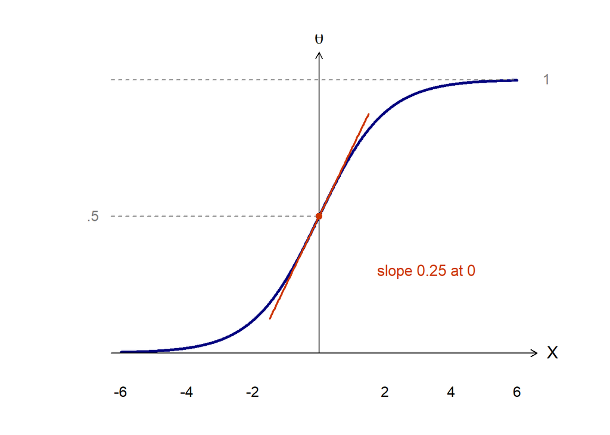

- $\Lambda$ is an S-surve, flat near 0 and 1, steepest at $\theta = 0.5$ ($X'\beta = 0$). Any real $X'\beta$ ($p$) lands inside (0, 1)
- The slope of $X'\beta$ is $\theta(1-\theta)$: one unit moves the probability by up to 0.25 in the middle and almost nothing in the tails.

**Note**

$$\theta=\Lambda(\eta)=\frac{e^\eta}{1+e^\eta},
\qquad \eta=X'\beta$$

$$\frac{d\theta}{d\eta}
=
\frac{e^\eta(1+e^\eta)-e^\eta e^\eta}{(1+e^\eta)^2}
=
\frac{e^\eta}{(1+e^\eta)^2}$$

$$\theta(1-\theta)
=
\frac{e^\eta}{1+e^\eta}
\frac{1}{1+e^\eta}
=
\frac{e^\eta}{(1+e^\eta)^2}$$

$$\boxed{\frac{d\theta}{d(X'\beta)}=\theta(1-\theta)}$$

- Only 0s and 1s are observed on the vertical axis

### Connect Logit to Log Likelihood $\bigstar$

$$\ell(\beta)
=
\sum_{i=1}^{n}
\left[
y_i\log p_i
+
(1-y_i)\log(1-p_i)
\right]
=
\sum_{i=1}^{n}
\left[
y_iX_i'\beta
-
\log\left(1+e^{X_i'\beta}\right)
\right]$$

Or

$$\log\left(\frac{p_i}{1-p_i}\right)
=
X_i'\beta,
\qquad
\log(1-p_i)
=
-\log\left(1+e^{X_i'\beta}\right).$$

### Newton’s Method

$$\beta^{[t+1]}
=
\beta^{[t]}
+
\mathcal{I}\left(\beta^{[t]}\right)^{-1}
S\left(\beta^{[t]}\right),
\qquad
S(\beta)
=
\sum_i (y_i-p_i)X_i,
\qquad
\mathcal{I}(\beta)
=
\sum_i p_i(1-p_i)X_iX_i'$$

### Interpret the Coefficient $\bigstar$

If $\hat{\beta} = 0.391$

$$\begin{array}{llll}
\hline
\text{Scale}
&
\text{Quantity}
&
\hat{\beta}=0.391\text{ says}
&
\\
\hline
\text{Log-odds}
&
\log\left(\dfrac{p}{1-p}\right)=X'\beta
&
\text{one more word adds }0.391
&
\text{linear, not intuitive}
\\
\text{Odds}
&
\dfrac{p}{1-p}=e^{X'\beta}
&
\text{odds multiply by }e^{0.391}=1.48
&
\text{the odds ratio}
\\
\text{Probability}
&
p=\Lambda(X'\beta)
&
\text{depends on where you start}
&
\text{what we care about}
\\
\hline
\end{array}$$

**Warning**

An odds ratio is not a risk ratio and **not a difference in probabilities**.

Report on the probability scale, and say *for whom*.

**TipConversion Across Scales**

1. Start from the linear predictor $X'\beta$
2. Convert log-odds to odds $odds = p/(1-p)= exp(X'\beta)$
3. Convert odds to probability $p = exp(X'\beta)/(exp(X'\beta)+1)$

### Average Marginal Effect $\bigstar$

For one person, the slope of the probability with respect to $X_j$ is $\frac{\partial p_i}{\partial X_{ij}} = p_i(1-p_i)\beta_j$, so $\beta_j$ is scaled by where the person sits on the S-curve

- **Average Marginal Effect (AME)**: compute the marginal effect separately for every actual observation, then average those marginal effects.
- **Marginal Effect at the Mean (MEM):** create one hypothetical observation with every covariate set to its sample mean, compute its predicted probability, and then compute the marginal effect at that point.

`avg_slopes()` reports both MEM and AME

**AME** (observed-value approach; Hanmer and Kalkan 2013) is recommended, because:

- An “average” case may not correspond to any real person, so MEM can evaluate the model at an unrealistic combination of covariates.
- For non-linear models, the effect of $X_i$ on $p_i$ on where person $i$ sits. (see the call-out under [**Connect to Log Likelihood**].)

#### Calculate SE of the AME

- Delta Method
- Simulation
- Bootstrap

**Never build an interval on the log-odds scale and transform its endpoints if what you want is an interval for a difference in probabilities.**

**Note**

An example:

In a logit regression

$$\text{logit}(p)=\log\left(\frac{p}{1-p}\right)=\eta$$

Its inversion
$$p = \eta^-1 = \frac{e^\eta}{1+e^\eta}$$

If we want to compare two log-odds $\eta_1=\beta_0+\beta_1,\qquad \eta_0=\beta_0$

The difference of probability is

$$\Delta p=p_1-p_0=\frac{e^{\eta_1}}{1+e^{\eta_1}}-\frac{e^{\eta_0}}{1+e^{\eta_0}}$$

And

$$\text{logit}^{-1}(\eta_1-\eta_0)=\frac{e^{\eta_1-\eta_0}}{1+e^{\eta_1-\eta_0}}$$

$$\text{logit}^{-1}(\eta_1)-\text{logit}^{-1}(\eta_0)=\frac{e^{\eta_1}}{1+e^{\eta_1}}-\frac{e^{\eta_0}}{1+e^{\eta_0}}$$

Clearly

$$\text{logit}^{-1}(\eta_1-\eta_0)\neq\text{logit}^{-1}(\eta_1)-\text{logit}^{-1}(\eta_0)$$

## Calculate AME: Example from the Mid-Term $\bigstar$

Pager (2003, AJS) sent matched pairs of testers to apply for 350 entry-level jobs in Milwaukee. The outcome is a callback (0/1). Testers were white or Black, and in each pair one presented a criminal record.

Pager reports callback rates of 34% (white, no record), 17% (white, record), 14% (Black, no record), and 5% (Black, record). Her Appendix Table B1 fits a logit of callback on $record$, $Black$, and their product (intercept rounded; the table also carries two controls, so the model’s predictions sit slightly off the raw rates):

| Variable | $\hat{\beta}$ |
| --- | --- |
| Intercept | $-0.66$ |
| Criminal record | $-0.99$ |
| Black | $-1.25$ |
| Record $\times$ Black | $-0.29$ |

### Answer

The estimated logistic regression model is

$$\begin{equation}
\operatorname{logit}(p_i)
= -0.66 - 0.99 Record_i - 1.25 Black_i
- 0.29(Record_i \times Black_i),
\end{equation}$$

The predicted probability is calculated as

$$\begin{equation}
\hat{p}_i
= \frac{\exp(\hat{\eta}_i)}
{1+\exp(\hat{\eta}_i)}.
\end{equation}$$
For White testers without a criminal record:

$$\begin{equation}
\hat{p}_{W,0}
= \frac{\exp(-0.66)}
{1+\exp(-0.66)}
= 0.3407.
\end{equation}$$

For White testers with a criminal record:

$$\begin{equation}
\hat{p}_{W,1}
= \frac{\exp(-0.66-0.99)}
{1+\exp(-0.66-0.99)}
= 0.1611.
\end{equation}$$

For Black testers without a criminal record:

$$\begin{equation}
\hat{p}_{B,0}
= \frac{\exp(-0.66-1.25)}
{1+\exp(-0.66-1.25)}
= 0.1290.
\end{equation}$$

For Black testers with a criminal record:

$$\begin{equation}
\hat{p}_{B,1}
= \frac{\exp(-0.66-0.99-1.25-0.29)}
{1+\exp(-0.66-0.99-1.25-0.29)}
= 0.0395.
\end{equation}$$

Since half of the testers are White and half are Black, the average marginal effect of a criminal record is

$$\begin{align}
AME
&= \frac{1}{2}
(\hat{p}_{W,1}-\hat{p}_{W,0})
+ \frac{1}{2}
(\hat{p}_{B,1}-\hat{p}_{B,0}) \\
&= \frac{1}{2}(0.1611-0.3407)
+ \frac{1}{2}(0.0395-0.1290) \\
&\approx \boxed{-0.1345}.
\end{align}$$
Based on the logistic regression model, having a criminal record is associated with a 13.45-percentage-point reduction in the predicted probability of receiving a callback, averaging equally across White and Black job applicants.

## Probit $\bigstar$

$$p_i=\Phi(X_i'\beta)$$

- $\Phi$ is slightly narrower than $S$.

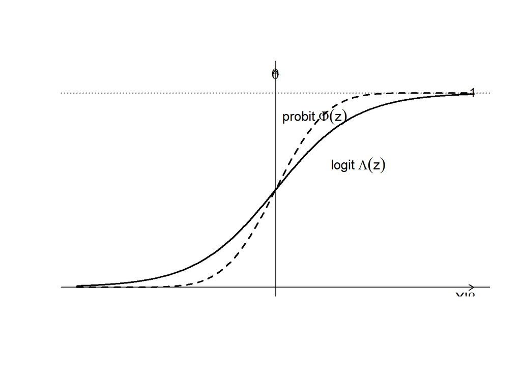

## Logit or Probit $\bigstar$

- **Default: Logit**
- Probit: when the next step needs a normal, e.g., selection models, bivariate probit, or a subfield convention.
- **Never compare raw coefficients across nested models or across groups**
  - Because adding a covariate rescales all the coefficients
  - Instead, **compare AMEs or predicted probabilities**
- Usually the AMEs from logit and probit are similar

## Interactions in Nonlinear Models $\bigstar$

$$\begin{array}{lll}
\hline
&
\text{log-odds scale}
&
\text{probability scale}
\\
\hline
\text{no product}
&
\text{one slope, }\beta_1,\text{ forced equal across }X_2
&
\text{differs across }X_2\text{ anyway, by }p_i(1-p_i)\text{ only}
\\
\text{with product}
&
\beta_1+\beta_{12}X_2,\text{ the data choose }\beta_{12}
&
\text{differs by }p_i(1-p_i)\text{ and by }\beta_{12}
\\
\hline
\end{array}$$

- **Always include the product whenever the question is whether X1’s effect differs by X2.**
  - The two models agree on probabilities only when $\hat{\beta}_{12} \approx 0$ otherwise the no-product model has the wrong probabilities in the cells.
- Report the interaction as a difference in AMEs of X1 between the X2 groups, with an interval.

**ImportantRecommendations for Nonlinear Interaction Effects**

Mize, Trenton D. 2019. “Best Practices for Estimating, Interpreting, and Presenting Nonlinear Interaction Effects.” *Sociological Science* 6: 81-117.

1. Include a product (interaction) term in the model if you want to investigate whether the effect of one independent variable is contingent on the level of a second independent variable.
   - If the interaction effect is false, the only cost is additional degree of freedom
   - If the interaction effect is true, omitting it can cause incorrect estimation
2. Ignore the coefficient of the product term. It does not necessarily provide accurate information about the significance, magnitude, or even the direction of the underlying interaction effect on the predictions.
3. Plot the predictions to determine the nature of the underlying interaction effect on the metric of interest.
4. Determine the size and significance of the effects of interest using marginal effects, not regression coefficients.
5. Use tests of second differences (whether two marginal effects are equal) to determine whether an interaction effect is significant for specific values of interest of your independent variables.
   - You should not decide whether two groups differ by easily checking whether their separate confidence intervals overlap.
   - **Rule of thumb**
     - If the two CIs **do not overlap**, then there is evidence that the two estimates differ at roughly the $\alpha$ level.
     - If the two CIs **do overlap**, the two estimates can **still be statistically significantly different**.
       - Why: the two estimates may share covariance.
         - $SE(\hat\theta_1-\hat\theta_2) = \sqrt{\operatorname{Var}(\hat\theta_1) + \operatorname{Var}(\hat\theta_2) -2\operatorname{Cov}(\hat\theta_1,\hat\theta_2)}$
6. Absent substantive or theoretically interesting values of the focal independent or control variables to test the interaction effect, use average marginal effects to summarize whether there is an interaction effect present on average in the data.

# Several Categories

## Multinomial Logit $\bigstar$

The categories have no order

$$\ell
=
\sum_{i=1}^{n}
\sum_{j=1}^{J}
\mathbf{1}\{Y_i=j\}\log p_{ij}$$

$$\log\left(\frac{p_{ij}}{p_{iJ}}\right)=X_i'\beta_j,\qquad j=1,\dots,J-1$$

$$\begin{aligned}
p_{ij}
&=
p_{i,\mathrm{base}}\,e^{X_i'\beta_j}
&& \text{exponentiate the }j\text{th line}
\\[4pt]
1
&=
\sum_j p_{ij}
=
p_{i,\mathrm{base}}
\left(
1+\sum_{m\neq \mathrm{base}} e^{X_i'\beta_m}
\right)
&& \text{add up all }J\text{ categories; the base contributes }e^0=1
\\[4pt]
p_{i,\mathrm{base}}
&=
\frac{1}{
1+\sum_{m\neq \mathrm{base}} e^{X_i'\beta_m}
}
&& \text{solve for the base}
\\[4pt]
p_{ij}
&=
\frac{
e^{X_i'\beta_j}
}{
1+\sum_{m\neq \mathrm{base}} e^{X_i'\beta_m}
}
&& \text{substitute back: the multinomial logit}
\end{aligned}$$

## Ordered Logit $\bigstar$

**TipLatent Variable**

Latent variable is very useful for understanding ordered logit models

(adapted from Richard Williams, *Ordered Logit Models – Basic & Intermediate Topics*)

1. In the ordered logit model, there is an observed ordinal variable, $Y$.
2. $Y$, in turn, is a function of another variable $Y^*$, that is not measured.

   a. The latent continous variable $Y^*$ determines the value of observed variable $Y$

   b. $Y^*$ has various threshold points $\tau$. The value of $Y$ depends on whether or not you have crossed a particular threshold. For example, when $J = 3$

   $Y_i$ = 1 if $Y_i^* \le \tau_1$

   $Y_i$ = 2 if $\tau_1 \le Y_i^* \le \tau_2$

   $Y_i$ = 3 if $\tau_2 \le Y_i^*$

   c. In general,

$$\begin{aligned}
Y_i^* &= \mu_i + \varepsilon_i, \qquad \varepsilon_i \sim f_L(0,1), \\
\mu_i &= X_i'\boldsymbol{\beta}, \\
Y_i &= m \iff \tau_{m-1} < Y_i^* \le \tau_m, \qquad \forall\, m \in \{1,\ldots,M\}.
\end{aligned}$$

The categories are ordered

The probability of being at or below each level:

$$\log\left(
\frac{\Pr(Y_i\le j)}
{\Pr(Y_i>j)}
\right)
=
\tau_j-X_i'\beta,
\qquad
j=1,\ldots,J-1$$

$$\quad\Longrightarrow\quad
\Pr(Y_i\le j)
=
\Lambda\left(\tau_j-X_i'\beta\right).$$

- $\hat{\beta}$ reads like a logit coefficient, it is the same for each category
- $\tau_j$ is like a intercept or gate

**Note**

Base on the latent variable model:

$$\text{Pr}(Y_i \le j) = \text{Pr}(Y_i^* \le \tau_j)$$

Since $Y_i^* = \mu_i + \varepsilon_i$,

$$\begin{aligned}
\Pr(Y_i\le j)& =\Pr(Y_i^*\le\tau_j) \\
&= \Pr(X_i'\beta+\varepsilon_i\le\tau_j) \\
&= \Pr(\varepsilon_i \le \tau_j - X_i'\beta )
\end{aligned}$$

It means, how small should the error need to be to make the latent outcome below the threshold

For logit model, the key assumption is $\varepsilon_i \sim \text{Logistic}(0, 1)$

And the cumulative distribution function of $\text{Logistic}(0, 1)$ is

$$F_L(z)=\Lambda(z)=\frac{e^z}{1+e^z}=\frac{1}{1+e^{-z}}.$$

So $\Pr(\varepsilon_i\le z)=\Lambda(z)$ (definition of cumulative distribution function)

Set $z=\tau_j-X_i'\beta$, then

$$\boxed{\Pr(Y_i\le j)=\Lambda(\tau_j-X_i'\beta)}$$

Then

$$\Pr(Y_i\le j)=\frac{\exp(\tau_j-X_i'\beta)}{1+\exp(\tau_j-X_i'\beta)}, \quad \Pr(Y_i>j)=1-\Pr(Y_i\le j) = \frac{1}{1+\exp(\tau_j-X_i'\beta)}$$

The cumulative odds is

$$\frac{\Pr(Y_i\le j)}{\Pr(Y_i>j)}=\frac{\frac{\exp(\tau_j-X_i'\beta)}{1+\exp(\tau_j-X_i'\beta)}}{\frac{1}{1+\exp(\tau_j-X_i'\beta)}}=\exp(\tau_j-X_i'\beta)$$
Take the log

$$\boxed{\log\frac{\Pr(Y_i\le j)}{\Pr(Y_i>j)}=\tau_j-X_i'\beta}$$

### Probabilities $\bigstar$

$$p_{ij}=\Lambda(\tau_j-X_i'\beta)-\Lambda(\tau_{j-1}-X_i'\beta)$$

**Note**

**Example:**

$$\begin{array}{lrrrr}\hline
& \hat{\beta} & z & \text{cutpoint} & \hat{\tau}\\ \hline
\text{parents' education} & 0.208 & 19.9 & <\mathrm{HS}\mid \mathrm{HS} & 1.84\\
\text{vocabulary} & 0.358 & 18.6 & \mathrm{HS}\mid \text{junior college} & 5.21\\
\text{female} & 0.335 & 5.2 & \text{junior college}\mid \text{bachelor's} & 5.67\\
\text{black} & -0.024 & -0.3 & \text{bachelor's}\mid \text{graduate} & 7.36\\ \hline
\end{array}$$

$$\begin{array}{lrrrrrr}\hline
& X_i'\hat{\beta} & <\mathrm{HS} & \mathrm{HS} & \mathrm{JC} & \mathrm{BA} & \mathrm{grad}\\ \hline
\text{A: parents 12 yrs, vocabulary 5, male, white} & 4.29 & 0.08 & 0.64 & 0.08 & 0.16 & 0.04\\
\text{B: parents 16 yrs, vocabulary 8, female, white} & 6.53 & 0.01 & 0.20 & 0.09 & 0.40 & 0.30\\ \hline
\end{array}$$

For A:

$$\begin{aligned}
P(A=\mathrm{HS})&=\Lambda(5.21-4.29)-\Lambda(1.84-4.29) \\
&=\frac{e^{0.92}}{1+e^{0.92}}-\frac{e^{-2.45}}{1+e^{-2.45}} \\
&\approx0.715-0.079\\
&=0.636
\end{aligned}$$

### Proportional Assumption $\bigstar$

**ordered logit model = proportional odds model = parallel lines model = parallel regressions model**

Why?

$$\log\left(\frac{\Pr(Y_i \le j)}{\Pr(Y_i > j)}\right)
= \tau_j - X_i^\prime\beta
\quad \Longleftrightarrow \quad
\log\left(\frac{\Pr(Y_i > j)}{\Pr(Y_i \le j)}\right)
= X_i^\prime\beta - \tau_j.$$

Then for each category $j$

$$OR=e^{\beta_k}$$

# Counts

## Poisson Regression $\bigstar$

$$\theta_i = e^{X_i'\beta}, \qquad \log{\theta_i} = X_i'\beta$$

- $e^\hat{\beta}$ = rate
- Why not use $\log{y}$: $\log{0}$ is undefined.

## Overdispersion $\bigstar$

Poisson has one parameter, its mean equals to its variance

$$\theta = Var(Y_i|X_i) = E(Y_i|X_i)$$

Over dispersion has a larger variance than the mean

- Use `AER::dispersiontest` to examine the overdispersion

#### Repairs for Overdispersion (adjust the SE)

$$\begin{array}{lll}
\hline
\text{Repair}
&
\text{Belief about }\operatorname{Var}(Y_i\mid X_i)
&
\text{What changes}
\\
\hline
\text{Quasi-Poisson}
&
\phi\theta_i,\ \text{one multiple everywhere}
&
\text{every SE, by one factor }\sqrt{\hat{\phi}}
\\
\text{Negative binomial}
&
\theta_i+\theta_i^2/\alpha,\ \text{grows faster than the mean}
&
\text{the likelihood: }\hat{\beta}\text{ and SEs}
\\
\text{Robust (sandwich)}
&
\text{none; use the squared residuals as they are}
&
\text{SEs only, each on its own}
\\
\hline
\end{array}$$

## Excess Zeros $\bigstar$

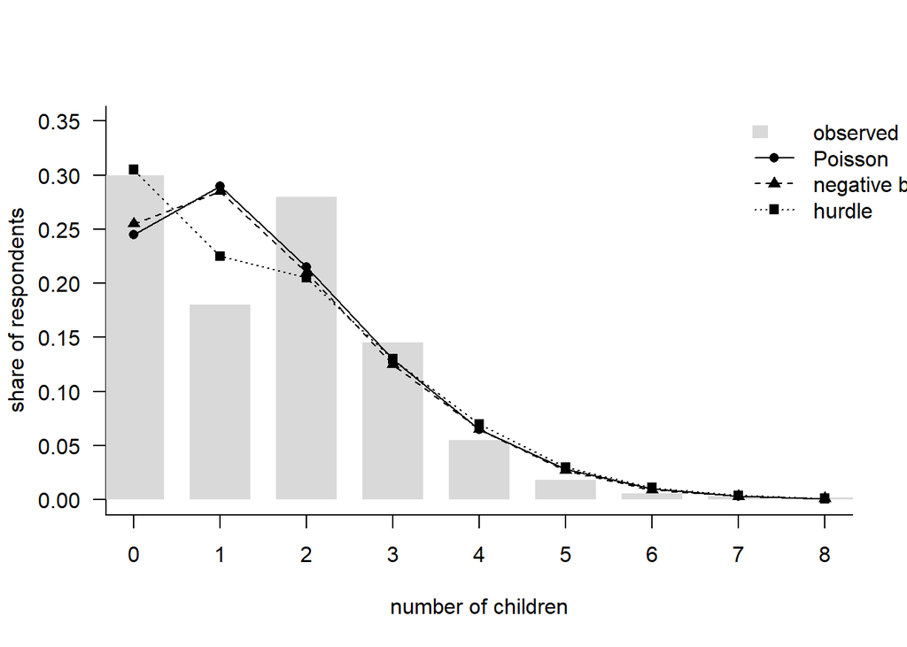

**Two solutions**

- **Hurdle:** a logit for zero versus positive, then a truncated count model for the positives. `pscl::hurdel`
- **Zero-inflated**: a mixture; a share of “structural zeros” who could never have a positive count, the rest a count model that can also produce zeros. `pscl::zeroinfl`

## How to Decide $\bigstar$

1. Start with **Poisson**, **robust SEs**. Coefficients are right for the mean under any variance
2. Run the **overdispersion test**. If it rejects and you need a likelihood (prediction, AIC, LR against a bigger model), fit the **negative binomial**.
3. Compare the **observed and predicted distribution** of counts, as in the figure. **A zero problem is visible before any test**.
4. **Hurdle or zero-inflated**: choose on substance. Hurdle when crossing from zero to one is a different process (having any children, ever being arrested). Zero-inflated when some zeros are a different kind of person (a nonsmoker’s zero cigarettes versus a smoker’s zero today). Then **AIC or BIC** between them; they are not nested.
5. **Never compare by fit alone across models fitted to different rows.**

# Multilevel

## Why not OLS with Clustered SEs $\bigstar$

$$Y_{ij} = \beta_0 + \beta_1X_{1ij} + \beta_2X_{2j} + u_{j} + e_{ij}$$

- $u_j$ how far the group is from the mean of groups
- $e_{ij}$ the individuals own deviation

Three ways to do with $u_j$

- **Clustered OLS**: split $\epsilon_{ij} = v_g + \eta_{ig}$ , but does not estimating $u_j$ or its variance
- **Fixed effects:** estimate every $u_j$, but it is absorbed
- **Multilevel Model:** treats $u_j$ as draws from a distribution and estimates the variance.

## The Random-Intercept Model $\bigstar$

$$Y_{ij} = \beta_0 + \beta_1X_{1ij} + \beta_2X_{2j} + \mu_{j} + e_{ij},
\qquad
u_j\sim N(0,\tau^2),
\qquad
e_{ij}\sim N(0,\sigma^2)$$

- Each group has its own intercept $\beta_0 + \mu_j$
- $\text{TotalVar}(Y_{ij}) = \tau^2 + \sigma^2$
  - $\tau^2$ : between-group variance
  - $\sigma^2$ : within-group variance
- Individuals in each group share the same $\mu_j$, so $Cov(Y_{ij}, Y_{i'j}) = \tau^2$ . The model is the correction of clustering errors.

**Important**

As long as the multilevel covariance structure is correctly specified, there is no need to cluster SEs

## Two Assumptions about $\mu_j$ $\bigstar$

1. $u_j\sim N(0,\tau^2)$. The distribution of **deviation from the overall intercept** (random effects) is a normal distribution with mean zero.
2. $u$ is uncorrelated with $X_j$, so $E[\mu_i | X_j] = 0$. The group random effect is **mean-independent of the covariates**

## Intraclass Correlation $\bigstar$

$$\text{ICC} = \frac{\hat{\tau}^2}{(\hat{\tau}^2)+\hat{\sigma}^2}$$

**Test of** $\hat{\tau}$: LR against OLS (without $u$)

## When You Need a Random Intercept $\bigstar$

1. **The split itself is the finding**. You want to know the ICC
2. **A group-level variable with few groups**. Clustered SEs are unreliable with a small number of groups

Otherwise, OLS is enough.

**NoteWhy clustered SEs are unreliable with a small number of groups**

The estimator of clustered SEs is
$$\widehat V_{CR}(\hat\beta)
=
c(X'X)^{-1}
\left(
\sum_{g=1}^G
X_g'\hat e_g\hat e_g'X_g
\right)
(X'X)^{-1}$$

$$c
=
\frac{G}{G-1}
\frac{n-1}{n-k} \qquad (CR1)$$

The consistency relies on $G \rightarrow \infty$. With small $G$, there are only a few independent cluster-level contributions, so the estimated variance is noisy and often too small.